# Assignment 2: Summarizing and visualizing data - SOLUTIONS

Modern Research Methods

**Objectives**

By the end of this assignment, you should:

- understand how to derive information from data ( `summarize`, `mutate`, `group_by`)
- understand how to make and modify a basic plot using ggplot

This assignment is due Thursday, February 6 at noon. Please turn your .html AND .Rmd files into Canvas. Your .Rmd file should knit without an error before turning in the assignment.

The first few excercises concern the data `babynames` again. The dataset is included in the “babynames” package.

1. a Trim babynames to just the rows that contain your name and either male or female. b Trim the result to just the columns that will appear in your graph (not strictly necessary, but useful practice). [c] Plot the results as a line graph with year on the x axis and prop on the y axis

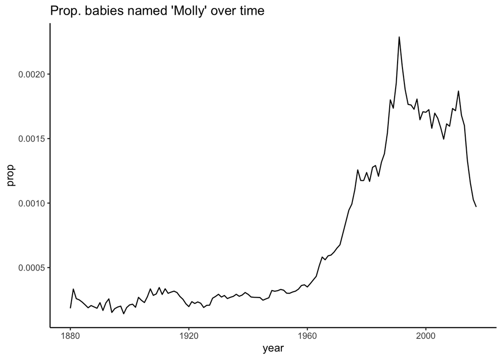

```r
molly_over_time <- babynames %>%
  filter(name == "Molly", sex == "F") %>%
  select(year, prop)

ggplot(molly_over_time) +
  geom_line(mapping = aes(x = year, y = prop)) +
  ggtitle("Prop. babies named 'Molly' over time") +
  theme_classic()
```

2. Use summarise() to compute three statistics about the data: a The first (minimum) year in the dataset b The last (maximum) year in the dataset [c] The total number of children represented in the data

```r
babynames %>%
  summarise(first = min(year),
            last = max(year),
            total = sum(n))
```

```
## # A tibble: 1 x 3
##   first  last     total
##   <dbl> <dbl>     <int>
## 1  1880  2017 348120517
```

The first year in the data set is 1880. The last year in the dataset is 2017. There are 348120517 children represented in the data.

3. Extract the rows where name == “Washington”. Then use summarise() and a summary functions to find: a The total number of children named Washington b The year with the most babies named Washington.

## a

```r
babynames %>%
  filter(name == "Washington") %>%
  summarise(total = sum(n))
```

```
## # A tibble: 1 x 1
##   total
##   <int>
## 1  2578
```

There are 2578 babies named “Washington”.

## b

```r
babynames %>%
  filter(name == "Washington") %>%
  arrange(-n) %>%
  summarise(total = sum(n),
            year_most_babies_Washington = first(year))
```

```
## # A tibble: 1 x 2
##   total year_most_babies_Washington
##   <int>                       <dbl>
## 1  2578                        1921
```

```r
# OR

babynames %>%
  filter(name == "Washington") %>%
  group_by(year) %>%
  summarise(total = sum(n)) %>%
  filter(total == max(total))
```

```
## # A tibble: 1 x 2
##    year total
##   <dbl> <int>
## 1  1921    60
```

```r
# OR

babynames %>%
  filter(name == "Washington") %>%
  filter(n == max(n))
```

```
## # A tibble: 1 x 5
##    year sex   name           n      prop
##   <dbl> <chr> <chr>      <int>     <dbl>
## 1  1921 M     Washington    60 0.0000527
```

The year with the most babies named “Washington” is 1921.

4. Use group_by(), summarise(), and arrange() to display the ten most popular names. Compute popularity as the total number of children of a single gender given a name.

```r
ten_popular_names <- babynames %>%
  group_by(name, sex) %>%
  summarise(total = sum(n)) %>%
  arrange(desc(total)) %>%
  ungroup() %>%
  slice(1:10)

kable(ten_popular_names)
```

| name | sex | total |
| --- | --- | --- |
| James | M | 5150472 |
| John | M | 5115466 |
| Robert | M | 4814815 |
| Michael | M | 4350824 |
| Mary | F | 4123200 |
| William | M | 4102604 |
| David | M | 3611329 |
| Joseph | M | 2603445 |
| Richard | M | 2563082 |
| Charles | M | 2386048 |

5. Use group_by to calculate and then plot the number of children born each year over time.

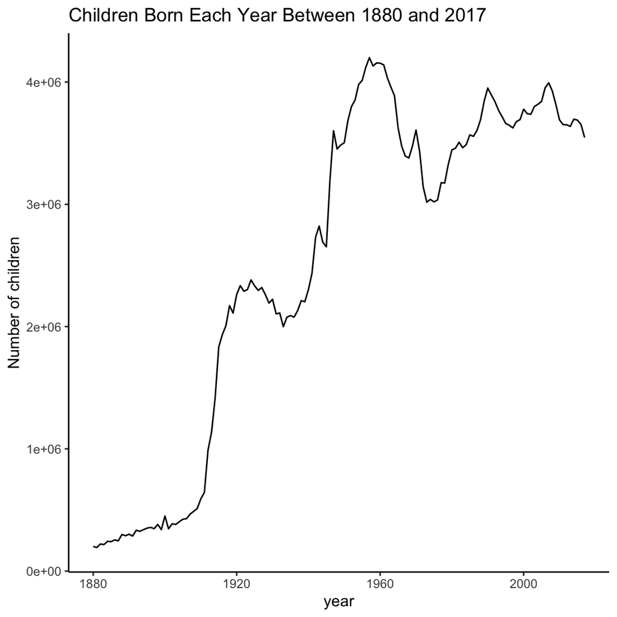

```r
babies_born_over_time <- babynames %>%
  group_by(year) %>%
  summarise(n_children = sum(n))

ggplot(babies_born_over_time, mapping = aes(x = year, y = n_children)) +
  geom_line() +
  ggtitle("Children Born Each Year Between 1880 and 2017") +
  ylab("Number of children") +
  theme_classic()
```

The final exercises concern the object complexity norms for the Lewis and Frank (2016) dataset that we have talked about in class. In the experiment, we asked participants to rate a random sample of 10 (out of 60) objects in terms of their conceptual complexity. They gave their responses using a slider scale where 0 = simple, and 1 = complex (and all values in between were possible). We collected data from 2 samples of participants. The data are in the data frame located at `data/lewis_object_complexity_norms_by_participant.csv`. Each variable is described below.

- `sample` - indicates whether the participants were from sample one or sample two.
- `participant_id` - unique identifier for each participant.
- `object_id`- unique idenfitier for each object (if you’re curious what the objects look like, you can find them [here](https://github.com/mllewis/RC/tree/master/stimuli/real%20novel%20objects)).
- `complexity_rating` - participant’s complexity rating.
1. Start by reading in the data frame using `read_csv()`. Then, for each object, calculate the mean, min, and max complexity rating (ignoring sample).

```r
lewis2016_data <- read_csv("data/lewis_object_complexity_norms_by_participant.csv")
obj_mean <- lewis2016_data %>%
  group_by(object_id) %>%
  summarize(mean_complexity = mean(complexity_rating),
            min_complexity = min(complexity_rating),
            max_complexity = max(complexity_rating))

obj_mean %>%
  slice(1:10) %>%
  kable()
```

| object_id | mean_complexity | min_complexity | max_complexity |
| --- | --- | --- | --- |
| 1 | 0.4523850 | 0.1693122 | 0.8208556 |
| 2 | 0.3562441 | 0.0026738 | 0.7673797 |
| 3 | 0.1471410 | 0.0000000 | 0.4278075 |
| 4 | 0.3789389 | 0.0000000 | 1.0000000 |
| 5 | 0.3524051 | 0.0000000 | 0.6764706 |
| 6 | 0.3574532 | 0.1203209 | 0.6470588 |
| 7 | 0.5161243 | 0.0855615 | 0.7673797 |
| 8 | 0.3880676 | 0.0000000 | 0.7005348 |
| 9 | 0.3358824 | 0.0000000 | 0.7326203 |
| 10 | 0.3775458 | 0.0053476 | 0.6746667 |

1. Plot the data. Use geom_bar(stat = “identity”) to plot the mean complexity for each object. Use geom_point() to plot the minimum complexity in red and the maximum complexity in blue. Sort the bars by the mean complexity rating from lowest to highest (see class slides for an example of this). Change the labels on the plot to make it maximally readable (xlab, ylab, ggtitle, and any other changes you think might help).

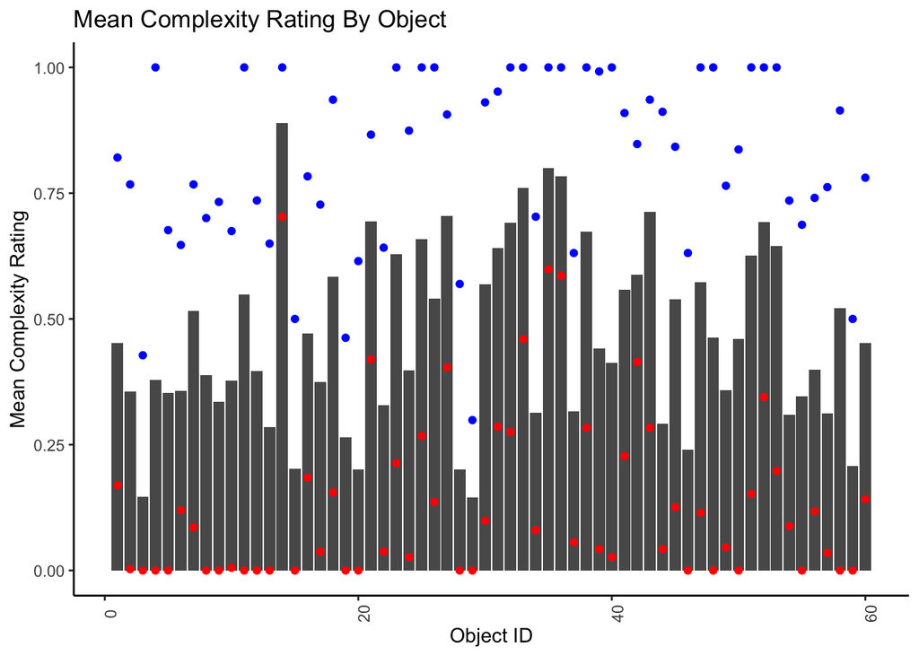

```r
ggplot(obj_mean, aes(x = object_id)) +
  geom_bar(aes(y = mean_complexity), stat = "identity") +
  geom_point(aes(y = min_complexity), color = "red") +
  geom_point(aes(y = max_complexity), color = "blue") +
  ggtitle("Mean Complexity Rating By Object") +
  xlab("Object ID") +
  ylab("Mean Complexity Rating") +
  theme_classic() +
  theme(axis.text.x = element_text(angle = 90))
```

1. Create a new variable called `complexity_range` that is the difference between the maximum and minimum complexity rating for each object. (Hint: You should use a tidyverse function that we have discussed in class.)

```r
obj_mean_with_range <- obj_mean %>%
  mutate(complexity_range = max_complexity - min_complexity)

obj_mean_with_range %>%
  slice(1:10) %>%
  kable()
```

| object_id | mean_complexity | min_complexity | max_complexity | complexity_range |
| --- | --- | --- | --- | --- |
| 1 | 0.4523850 | 0.1693122 | 0.8208556 | 0.6515434 |
| 2 | 0.3562441 | 0.0026738 | 0.7673797 | 0.7647059 |
| 3 | 0.1471410 | 0.0000000 | 0.4278075 | 0.4278075 |
| 4 | 0.3789389 | 0.0000000 | 1.0000000 | 1.0000000 |
| 5 | 0.3524051 | 0.0000000 | 0.6764706 | 0.6764706 |
| 6 | 0.3574532 | 0.1203209 | 0.6470588 | 0.5267380 |
| 7 | 0.5161243 | 0.0855615 | 0.7673797 | 0.6818182 |
| 8 | 0.3880676 | 0.0000000 | 0.7005348 | 0.7005348 |
| 9 | 0.3358824 | 0.0000000 | 0.7326203 | 0.7326203 |
| 10 | 0.3775458 | 0.0053476 | 0.6746667 | 0.6693191 |

1. For each object, for each sample, calculate the mean complexity rating and save it to a data frame called `participant_sample_mean`. Print the first 5 rows of your data frame. (note: you can print a prettier table by using the `kable()` function around the dataframe you want to output).

```r
participant_sample_mean <- lewis2016_data %>%
  group_by(object_id, sample) %>%
  summarize(mean_complexity = mean(complexity_rating))

participant_sample_mean %>%
  ungroup() %>%
  slice(1:5) %>%
  kable()
```

| object_id | sample | mean_complexity |
| --- | --- | --- |
| 1 | one | 0.4331551 |
| 1 | two | 0.4780250 |
| 2 | one | 0.4112299 |
| 2 | two | 0.2776929 |
| 3 | one | 0.1574866 |

1. Create a scatter plot with sample one on the x-axis and sample two on the y-axis. Add a line to fit the data.

This is a little tricky. The current dataframe is tidy (each observation is its own row), but to make a plot that puts sample 1 and sample 2 on different axes we need sample one and sample two to be their own columns. In other words, we need a dataframe that has three columns: `object_id`, `mean_complexity_sample_1`, `mean_complexity_sample_2`. To transform the current data frame into the one we need, we can use the function `pivot_wider()`. The code below does this for you.

Print the first 5 rows of `participant_sample_mean_wide`. Then plot the data with a scatter plot.

```r
participant_sample_mean_wide  <- participant_sample_mean %>%
  pivot_wider(names_from = "sample", values_from = "mean_complexity")

participant_sample_mean_wide %>%
  ungroup() %>%
  slice(1:5) %>%
  kable()
```

| object_id | one | two |
| --- | --- | --- |
| 1 | 0.4331551 | 0.4780250 |
| 2 | 0.4112299 | 0.2776929 |
| 3 | 0.1574866 | 0.1323616 |
| 4 | 0.4937611 | 0.2849934 |
| 5 | 0.3914884 | 0.3230926 |

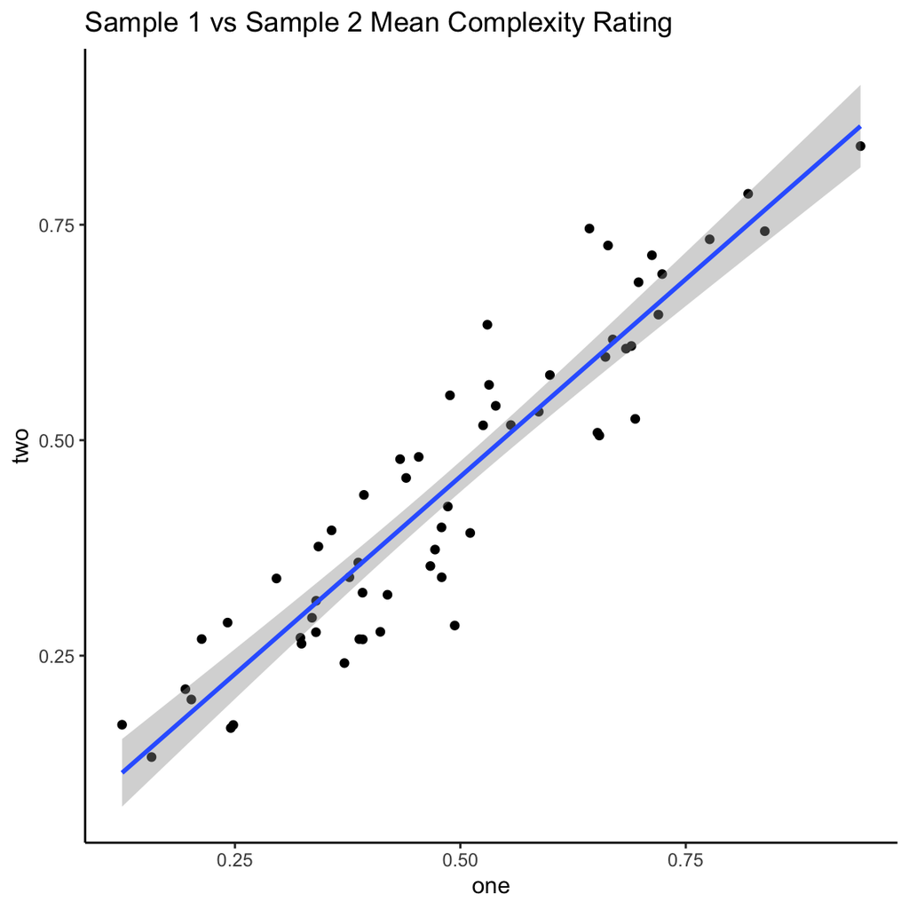

```r
ggplot(participant_sample_mean_wide, aes(x = one, y = two)) +
  geom_point() +
  geom_smooth(method= "lm") +
  ggtitle("Sample 1 vs Sample 2 Mean Complexity Rating") +
  theme_classic()
```

1. Choose your own geom! Look at the geoms on the cheat sheet and choose one to use with this data (other than geom_line, geom_point, geom_smooth, and geom_bar). Make a plot.